# An Introduction to Geoprocessing with Python

This is a very brief overview of how Python can be used to carry out common GIS tasks. We will begin with a quick outline of the advantages and disadvantages of using Python for GIS and then see Python in action with a small demonstration.

Link: https://ccchris-allen.github.io/

1. Python vs. Desktop GIS
   1. Advantages of Python
   2. Disadvantages of Python
2. Is Bigfoot a Cheesehead? Or, Mapping Bigfoot Sightings using Python
   1. Importing necessary Python modules
   2. Reading the GIS files
   3. Viewing the data
   4. Filtering our dataset by attribute
   5. How many sightings are there per state?
   6. What percentage of sightings are in Wisconsin?
3. Appendix
   1. Credits
   2. Data Sources
   3. Additional Links

## 1. Python vs. Desktop GIS

Traditional desktop GIS applications are powerful tools for reading, writing, and manipulating geospatial data. However, there are many compelling reasons for using programming languages such as Python for working with spatial data.

### Advantages of Python

- **Repeatability:** Using Python can help you automate tedious geoprocessing tasks. Python scripts can create a repeatable workflow for loading, manipulating, and writing data.
- **Extensibility:** Python has many great general purpose analysis modules, which can allow you to easily combine geoprocessing and non-spatial forms analysis (eg: data mining, statistical anlysis, text mining) into a single procedure. Setting up a similar workflow is often difficult (or impossible) when peforming geoprocessing in desktop GIS.
- **Affordability:** Python is free!
- **Cross-Platform:** Unlike some desktop GIS applications, Python can be run on macOS, Windows, Linux, etc.

### Disadvantages of Python

- **Less Graphical:** Desktop GIS software tends to prioritize the graphical view of geospatial data; by default, you see the geometry of your features. As we'll see below, you're able to view the geometry of GIS features in Python, but it's not as automatic as in desktop GIS.
- **Less Familiar:** In general, desktop software is more familiar to most of us, since we carry out most of our daily computing tasks in desktop programs that have user-friendly interfaces. Because of this, there is a learning curve when using Python, since programming involves using text commands to carry out tasks (which we'll see below).

## 2. Is Bigfoot a Cheesehead? Or, Mapping Bigfoot Sightings using Python

[figure not shown]

In this example, we'll pretend you're interested in learning about the distribution of Bigfoot sightings in mainland United States. We'll use the `geopandas` Python library to read and manipulate relevant geospatial data. We'll also try to answer a very important research question: **Is Bigfoot a cheesehead?**

**Note:** Don't worry about trying to understand every detail of the code shown here. This is merely intended to give you an overview of what's possible in Python.

### Importing necessary Python modules

Loading relevant modules is often the first thing done when working in Python. Modules are collections of code that provide specialized functions. In this case, we will rely on the `geopandas` module to perform geospatial functions.

**Note:** `geopandas` is a powerful tool for reading and writing data, while also having capabilities for performing the geometric operations that are essential for geospatial work. However, see the Additional Links section for other great Python geospatial modules.

```python
# Load the geopandas library, which will let us work with geospatial data
import geopandas

# This code helps us configure the appearance of our outputs (not important to understand right now)
%matplotlib inline
import matplotlib.pyplot as plt
plt.rcParams["figure.figsize"] = (12, 9)
```

### Reading the GIS files

Here, we load two shapefies by calling the `read_file` function:

1. `bigfoot_sightings.shp`: This is a point file where each point represents a Bigfoot sighting.
2. `cb_2016_us_state_5m.shp`: This is a polygon file of all states in the United States.

```python
sightings = geopandas.read_file('data/bigfoot_sightings.shp')
usa = geopandas.read_file('data/cb_2016_us_state_5m.shp')
```

### Viewing the data

Similar to desktop GIS, `geopandas` allows us to view geospatial data using a table view as well as a graphical view.

The table view allows us to see the attributes that are associated with our features.

```python
usa
```

|  | AFFGEOID | ALAND | AWATER | GEOID | LSAD | NAME | STATEFP | STATENS | STUSPS | geometry |
| --- | --- | --- | --- | --- | --- | --- | --- | --- | --- | --- |
| 0 | 0400000US01 | 1.311737e+11 | 4.593686e+09 | 01 | 00 | Alabama | 01 | 01779775 | AL | (POLYGON ((-88.04374299999999 30.517423, -88.0... |
| 1 | 0400000US02 | 1.477946e+12 | 2.453905e+11 | 02 | 00 | Alaska | 02 | 01785533 | AK | (POLYGON ((-133.655819 55.625617, -133.624921 ... |
| 2 | 0400000US04 | 2.941986e+11 | 1.027346e+09 | 04 | 00 | Arizona | 04 | 01779777 | AZ | POLYGON ((-114.799683 32.593621, -114.809393 3... |
| 3 | 0400000US08 | 2.684293e+11 | 1.175113e+09 | 08 | 00 | Colorado | 08 | 01779779 | CO | POLYGON ((-109.060253 38.599328, -109.059541 3... |
| 4 | 0400000US09 | 1.254264e+10 | 1.815476e+09 | 09 | 00 | Connecticut | 09 | 01779780 | CT | POLYGON ((-73.72777499999999 41.100696, -73.69... |
| 5 | 0400000US12 | 1.389242e+11 | 3.138604e+10 | 12 | 00 | Florida | 12 | 00294478 | FL | (POLYGON ((-80.751643 24.857254, -80.729063 24... |
| 6 | 0400000US13 | 1.491698e+11 | 4.741101e+09 | 13 | 00 | Georgia | 13 | 01705317 | GA | POLYGON ((-85.605165 34.984678, -85.4741053158... |
| 7 | 0400000US16 | 2.140429e+11 | 2.398670e+09 | 16 | 00 | Idaho | 16 | 01779783 | ID | POLYGON ((-117.242675 44.396548, -117.234835 4... |
| 8 | 0400000US18 | 9.279055e+10 | 1.536767e+09 | 18 | 00 | Indiana | 18 | 00448508 | IN | POLYGON ((-88.09566199999999 37.905808, -88.08... |
| 9 | 0400000US20 | 2.117533e+11 | 1.346236e+09 | 20 | 00 | Kansas | 20 | 00481813 | KS | POLYGON ((-102.051744 40.003078, -101.916696 4... |
| 10 | 0400000US22 | 1.119049e+11 | 2.374630e+10 | 22 | 00 | Louisiana | 22 | 01629543 | LA | (POLYGON ((-88.88145399999999 30.053202, -88.8... |
| 11 | 0400000US25 | 2.020444e+10 | 7.130621e+09 | 25 | 00 | Massachusetts | 25 | 00606926 | MA | (POLYGON ((-70.275526 41.310464, -70.260632 41... |
| 12 | 0400000US27 | 2.062323e+11 | 1.892918e+10 | 27 | 00 | Minnesota | 27 | 00662849 | MN | POLYGON ((-97.239209 48.968684, -97.2380249999... |
| 13 | 0400000US29 | 1.780527e+11 | 2.487575e+09 | 29 | 00 | Missouri | 29 | 01779791 | MO | POLYGON ((-95.773549 40.578205, -95.7685270000... |
| 14 | 0400000US30 | 3.769650e+11 | 3.866987e+09 | 30 | 00 | Montana | 30 | 00767982 | MT | POLYGON ((-116.049155 48.481247, -116.04915652... |
| 15 | 0400000US32 | 2.843293e+11 | 2.047351e+09 | 32 | 00 | Nevada | 32 | 01779793 | NV | POLYGON ((-120.005743 39.228664, -120.005142 3... |
| 16 | 0400000US34 | 1.905076e+10 | 3.541928e+09 | 34 | 00 | New Jersey | 34 | 01779795 | NJ | POLYGON ((-75.559102 39.629056, -75.5594459999... |
| 17 | 0400000US36 | 1.220530e+11 | 1.924310e+10 | 36 | 00 | New York | 36 | 01779796 | NY | (POLYGON ((-72.034958 41.255458, -72.029438 41... |
| 18 | 0400000US38 | 1.787118e+11 | 4.399094e+09 | 38 | 00 | North Dakota | 38 | 01779797 | ND | POLYGON ((-104.048652 48.865734, -104.048824 4... |
| 19 | 0400000US40 | 1.776637e+11 | 3.373836e+09 | 40 | 00 | Oklahoma | 40 | 01102857 | OK | POLYGON ((-103.002565 36.526588, -103.002188 3... |
| 20 | 0400000US42 | 1.158822e+11 | 3.396806e+09 | 42 | 00 | Pennsylvania | 42 | 01779798 | PA | POLYGON ((-80.519891 40.906661, -80.5190910000... |
| 21 | 0400000US45 | 7.786172e+10 | 5.070944e+09 | 45 | 00 | South Carolina | 45 | 01779799 | SC | POLYGON ((-83.35323800000001 34.728648, -83.34... |
| 22 | 0400000US46 | 1.963484e+11 | 3.380783e+09 | 46 | 00 | South Dakota | 46 | 01785534 | SD | POLYGON ((-104.057698 44.997431, -104.05021 44... |
| 23 | 0400000US48 | 6.766335e+11 | 1.902599e+10 | 48 | 00 | Texas | 48 | 01779801 | TX | POLYGON ((-106.645479 31.89867, -106.64084 31.... |
| 24 | 0400000US50 | 2.387347e+10 | 1.031125e+09 | 50 | 00 | Vermont | 50 | 01779802 | VT | POLYGON ((-73.43773999999999 44.045006, -73.43... |
| 25 | 0400000US54 | 6.226560e+10 | 4.899028e+08 | 54 | 00 | West Virginia | 54 | 01779805 | WV | POLYGON ((-82.64299699999999 38.16956, -82.639... |
| 26 | 0400000US72 | 8.868100e+09 | 4.923178e+09 | 72 | 00 | Puerto Rico | 72 | 01779808 | PR | (POLYGON ((-65.335701 18.349535, -65.329334 18... |
| 27 | 0400000US05 | 1.347715e+11 | 2.960192e+09 | 05 | 00 | Arkansas | 05 | 00068085 | AR | POLYGON ((-94.61791900000002 36.49941400000001... |
| 28 | 0400000US06 | 4.035011e+11 | 2.046672e+10 | 06 | 00 | California | 06 | 01779778 | CA | (POLYGON ((-118.603375 33.478098, -118.598783 ... |
| 29 | 0400000US10 | 5.047195e+09 | 1.398721e+09 | 10 | 00 | Delaware | 10 | 01779781 | DE | (POLYGON ((-75.570798 39.626768, -75.559445999... |
| 30 | 0400000US11 | 1.583650e+08 | 1.863340e+07 | 11 | 00 | District of Columbia | 11 | 01702382 | DC | POLYGON ((-77.119759 38.934343, -77.1045 38.94... |
| 31 | 0400000US15 | 1.663410e+10 | 1.177770e+10 | 15 | 00 | Hawaii | 15 | 01779782 | HI | (POLYGON ((-156.05722 19.742536, -156.052315 1... |
| 32 | 0400000US17 | 1.437887e+11 | 6.206694e+09 | 17 | 00 | Illinois | 17 | 01779784 | IL | POLYGON ((-91.512974 40.181062, -91.511073 40.... |
| 33 | 0400000US19 | 1.446676e+11 | 1.077808e+09 | 19 | 00 | Iowa | 19 | 01779785 | IA | POLYGON ((-96.639704 42.737071, -96.635886 42.... |
| 34 | 0400000US21 | 1.022663e+11 | 2.388771e+09 | 21 | 00 | Kentucky | 21 | 01779786 | KY | (POLYGON ((-89.405654 36.528165, -89.398685 36... |
| 35 | 0400000US23 | 7.988522e+10 | 1.174876e+10 | 23 | 00 | Maine | 23 | 01779787 | ME | (POLYGON ((-68.37659099999999 44.113762, -68.3... |
| 36 | 0400000US24 | 2.514775e+10 | 6.983312e+09 | 24 | 00 | Maryland | 24 | 01714934 | MD | (POLYGON ((-76.04861699999999 38.014843, -76.0... |
| 37 | 0400000US26 | 1.464553e+11 | 1.040316e+11 | 26 | 00 | Michigan | 26 | 01779789 | MI | (POLYGON ((-84.009664 46.101332, -83.987684 46... |
| 38 | 0400000US28 | 1.215299e+11 | 3.930506e+09 | 28 | 00 | Mississippi | 28 | 01779790 | MS | (POLYGON ((-88.510674 30.217021, -88.492378 30... |
| 39 | 0400000US31 | 1.989727e+11 | 1.356291e+09 | 31 | 00 | Nebraska | 31 | 01779792 | NE | POLYGON ((-104.053514 41.157257, -104.052666 4... |
| 40 | 0400000US33 | 2.318740e+10 | 1.028679e+09 | 33 | 00 | New Hampshire | 33 | 01779794 | NH | POLYGON ((-72.554232 42.860038, -72.555132 42.... |
| 41 | 0400000US35 | 3.141694e+11 | 7.557230e+08 | 35 | 00 | New Mexico | 35 | 00897535 | NM | POLYGON ((-109.050173 31.480004, -109.049843 3... |
| 42 | 0400000US37 | 1.259213e+11 | 1.347006e+10 | 37 | 00 | North Carolina | 37 | 01027616 | NC | (POLYGON ((-75.72680699999999 35.935844, -75.7... |
| 43 | 0400000US39 | 1.058331e+11 | 1.026460e+10 | 39 | 00 | Ohio | 39 | 01085497 | OH | (POLYGON ((-82.73570699999999 41.603361, -82.7... |
| 44 | 0400000US41 | 2.486043e+11 | 6.195106e+09 | 41 | 00 | Oregon | 41 | 01155107 | OR | POLYGON ((-124.552441 42.840568, -124.500141 4... |
| 45 | 0400000US44 | 2.677899e+09 | 1.323552e+09 | 44 | 00 | Rhode Island | 44 | 01219835 | RI | (POLYGON ((-71.36152 41.464831, -71.34707 41.4... |
| 46 | 0400000US47 | 1.067977e+11 | 2.355189e+09 | 47 | 00 | Tennessee | 47 | 01325873 | TN | POLYGON ((-90.309877 35.00975, -90.30689699999... |
| 47 | 0400000US49 | 2.128855e+11 | 6.999529e+09 | 49 | 00 | Utah | 49 | 01455989 | UT | POLYGON ((-114.052962 37.592783, -114.052472 3... |
| 48 | 0400000US51 | 1.022573e+11 | 8.528606e+09 | 51 | 00 | Virginia | 51 | 01779803 | VA | (POLYGON ((-75.999658 37.848198, -75.996859 37... |
| 49 | 0400000US53 | 1.721134e+11 | 1.255845e+10 | 53 | 00 | Washington | 53 | 01779804 | WA | (POLYGON ((-122.328343 48.021335, -122.321721 ... |
| 50 | 0400000US55 | 1.402736e+11 | 2.936139e+10 | 55 | 00 | Wisconsin | 55 | 01779806 | WI | (POLYGON ((-86.956198 45.352006, -86.953389 45... |
| 51 | 0400000US60 | 1.977591e+08 | 1.307244e+09 | 60 | 00 | American Samoa | 60 | 01802701 | AS | (POLYGON ((-168.163532 -14.536407, -168.159438... |
| 52 | 0400000US66 | 5.435583e+08 | 9.343350e+08 | 66 | 00 | Guam | 66 | 01802705 | GU | (POLYGON ((144.642331 13.241898, 144.649492 13... |
| 53 | 0400000US69 | 4.722767e+08 | 4.644268e+09 | 69 | 00 | Commonwealth of the Northern Mariana Islands | 69 | 01779809 | MP | (POLYGON ((146.033197 16.004517, 146.05429 16.... |
| 54 | 0400000US78 | 3.480131e+08 | 1.550245e+09 | 78 | 00 | United States Virgin Islands | 78 | 01802710 | VI | (POLYGON ((-64.634323 17.795891, -64.622142 17... |
| 55 | 0400000US56 | 2.514649e+11 | 1.861273e+09 | 56 | 00 | Wyoming | 56 | 01779807 | WY | POLYGON ((-111.056888 44.866658, -111.055629 4... |

The graphical view is helpful when we are particularly interested in the geometry of our features. We show the graphical view by using the `plot` function.

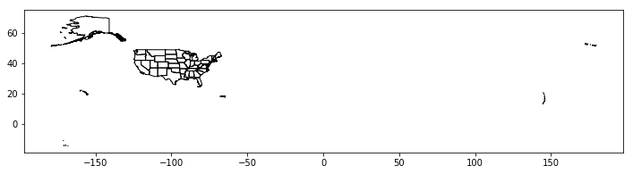

```python
usa.plot(color='white')
```

So far, we've only been looking at the `usa` dataset, but we can also plot the `sightings` layer on top of `usa`.

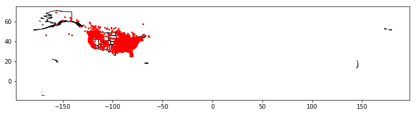

```python
base_layer = usa.plot(color='white')
sightings.plot(ax=base_layer, color='red')
```

### Filtering our dataset by attribute

From the plots above we can see that our `usa` layer contains many states and territories that are not part of mainland US, but luckily `geopandas` gives us the ability to filter our dataset by attribute. Since we only want to work with features within mainland US, we first create a list of features to filter out by inspecting the `NAME` attribute shown in the table above. Then we use the `query` function in `geopandas` to keep only the features that have a `NAME` attribute value that is **not** in our list.

```python
# NAME values that are not mainland features
not_mainland_names = ['American Samoa', 'Guam', 'Puerto Rico', 'United States Virgin Islands',
                       'Commonwealth of the Northern Mariana Islands', 'Alaska', 'Hawaii']

# Use `query` to keep only features where the NAME values is NOT in our list
mainland_usa = usa.query('NAME not in @not_mainland_names')
```

Now, we can again use the `plot` function to make sure our new dataset only contains features from mainland US. Looks good!

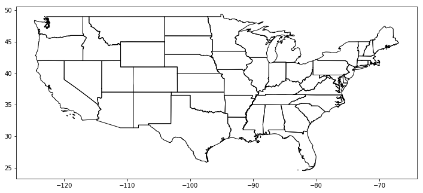

```python
mainland_usa.plot(color='white')
```

### How many sightings are there per state?

Now we'll use a spatial join to determine how many Bigfoot sightings have occurred in each state.

In `geopandas` we use the `sjoin` function to perform a spatial join. (Note: Ignore the "CRS does not match!" warning for now.)

```python
points_in_polygon = geopandas.sjoin(sightings, mainland_usa, how='inner', op='within')
```

Next we count the points in each state and create a new attribute called `SIGHTINGS_COUNT` to hold this count for each state.

```python
# These lines of code might look scary, but all you need to know is that this code aggregates
# all points within each state and creates a new attribute called SIGHTINGS_COUNT that reflects
# the number of sightings in that state.
counts = points_in_polygon.groupby('NAME').size()
counts = counts.to_frame('SIGHTINGS_COUNT').reset_index()
mainland_with_counts = mainland_usa.merge(counts)
```

We can now visialize our data as a choropleth map by telling the `plot` function that we would like to use the `SIGHTINGS_COUNT` attribute as our thematic variable.

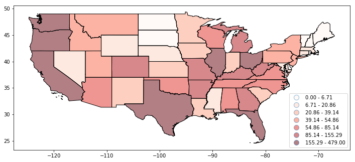

```python
mainland_with_counts.plot(column='SIGHTINGS_COUNT', cmap='Reds', scheme='quantiles', k=7, legend=True)
```

### What percentage of sightings are in Wisconsin?

Finally, we can find out if Sasquatch is a cheesehead! This is a rather silly example, so we'll take an equally silly (and simplistic) approach to answering this question by merely finding out what percentage of the total mainland US sightings are in Wisconsin.

First we select the Wisconsin feature and get the `SIGHTINGS_COUNT` value.

```python
wi_with_count = mainland_with_counts.query('NAME == "Wisconsin"')
wi_sightings = wi_with_count.SIGHTINGS_COUNT.iloc[0]
```

Next we find the total number of sightings in mainland US and then use this value to find the percentage of sightings that occurred in Wisconsin.

```python
mainland_total_sightings = mainland_with_counts.SIGHTINGS_COUNT.sum()
wi_percentage = 100 * wi_sightings / float(mainland_total_sightings)
```

We now simply print out the percentage.

```python
print "{0:.2f} percent of sightings are in WI.".format(wi_percentage)
```

```
1.81 percent of sightings are in WI.
```

#### Only about 2% of total sightings occurred in Wisconsin, so we must conclude that Bigfoot is NOT a cheesehead!

## 3. Appendix

### Credits

The idea for this notebook was inspired by work from [Joshua Stevens](http://www.joshuastevens.net/visualization/squatch-watch-92-years-of-bigfoot-sightings-in-us-and-canada/) and [Timothy Renner](https://timothyrenner.github.io/datascience/2017/06/30/finding-bigfoot.html).

### Data Sources

- Data on bigfoot sightings (`bigfoot_sightings.shp`) came from [Timothy Renner](https://data.world/timothyrenner/bfro-sightings-data).
- US state boundaries (`cb_2016_us_state_5m.shp`) came from the [Census Bureau](https://www.census.gov/geo/maps-data/data/cbf/cbf_state.html).

### Additional Links

This is a short list of other useful Python geospatial modules.

- [GDAL/OGR](https://pcjericks.github.io/py-gdalogr-cookbook/): A Python implementation of GDAL/OGR
- [arcpy](http://pro.arcgis.com/en/pro-app/arcpy/get-started/what-is-arcpy-.htm): ESRI's Python interface to ArcGIS.
- [fiona](https://github.com/Toblerity/Fiona): A user friendly interface for reading and writing geospatial data.
- [shapely](https://toblerity.org/shapely/manual.html): A module for performing geometric operations.
- pyproj: For working with map projections.